# База данных eICU. Разведочный анализ одной из таблиц

Sergei Vladimirov

2022-08-10

## О базе данных

[The electronic ICU (eICU) Collaborative Research Database](https://eicu-crd.mit.edu) сформирована на основе 200 тысяч госпитализаций в отделения реанимации в различных клиниках США в 2014-2015 гг.Она содержит анонимизированные показтели витальных функцах,демографические данные, информацию о диагнозах и лечении. Данные были собраны при помощи телемедицинской программы [Philips eICU](https://www.usa.philips.com/healthcare/resources/landing/teleicu) в парнерстве с лабораторией вычислительный физиологии Массачусетского технологического института.  
Доступ к данным дается после прохождения курса по защите прав субъектов клинических исследований и подписания соглашения о правилах использования данных.

База данных явялется реляционной — она состоит из трех десятков [взаимосвязанных таблиц](https://mit-lcp.github.io/eicu-schema-spy/relationships.html). Ниже будут приведены некоторые описательные статистики из одной из ключевых таблиц - таблицы patient.

## О таблице patient

В этой таблице содержатся анонимизированные идентификационные номера, демографические данные и административная информация.

Каждый пациент имеет уникальный индивидуальный номер (не меняется в случае повторной госпитализации), номер госпитализации (меняется при повторной госпитализации), номер госпитализации в интенсивную терапию(меняется при повторном попадании в реанимацию, в т.ч. в течение одной госпитализации). Таким образом, каждый пациент имеет только один UniquePid, но может иметь несколько других идентификационых номеров.

*Пример для наглядности – госпитализации и попадания в реанимацию сгруппированы по уникальным номерам и отсортированы по общему количеству госпитализаций. Взяты первые 10 пациентов.*

| Уникальный номер | Количество поступлений в стационар | Количество поступлений в реанимацию |
| --- | --- | --- |
| 021-239346 | 24 | 26 |
| 021-120471 | 24 | 26 |
| 015-76326 | 24 | 24 |
| 011-1993 | 22 | 22 |
| 027-37185 | 20 | 20 |
| 022-4233 | 19 | 19 |
| 006-100497 | 16 | 24 |
| 031-4227 | 15 | 15 |
| 002-77978 | 15 | 21 |
| 033-3184 | 14 | 14 |

Демографические данные включают возраст,этническую принадлежность,рост и вес. Согласно HIPAA, возраст [старше 89 лет](https://www.luc.edu/its/aboutits/itspoliciesguidelines/hipaainformation/18hipaaidentifiers/) является потенциальным деанонимирующим фактором, поэтому все пациенты старше 89 лет попали в группу (’>89’).

Административные данные содержат информацию о том, откуда поступил и куда выписан пациент, время поступления и выписки, тип отделения, диагноз, статус привыписке (жив/умер).

*Для ознакомления со всеми колонками table возьмем данные первого пациента из предыдущей таблицы*

| patientunitstayid | patienthealthsystemstayid | gender | age | ethnicity | hospitalid | wardid | apacheadmissiondx | admissionheight | hospitaladmittime24 | hospitaladmitoffset | hospitaladmitsource | hospitaldischargeyear | hospitaldischargetime24 | hospitaldischargeoffset | hospitaldischargelocation | hospitaldischargestatus | unittype | unitadmittime24 | unitadmitsource | unitvisitnumber | unitstaytype | admissionweight | dischargeweight | unitdischargetime24 | unitdischargeoffset | unitdischargelocation | unitdischargestatus | uniquepid |
| --- | --- | --- | --- | --- | --- | --- | --- | --- | --- | --- | --- | --- | --- | --- | --- | --- | --- | --- | --- | --- | --- | --- | --- | --- | --- | --- | --- | --- |
| 1988010 | 1577915 | Female | 35 | Caucasian | 310 | 836 | Diabetic ketoacidosis | 166.4 | 17:31:18 | -36 | Emergency Department | 2014 | 19:41:00 | 2974 | Home | Alive | Med-Surg ICU | 18:07:00 | Emergency Department | 1 | admit | 133.8 | 134.13 | 18:49:00 | 1482 | Acute Care/Floor | Alive | 021-239346 |
| 1989909 | 1579365 | Female | 37 | Caucasian | 310 | 836 | Emphysema/bronchitis | 165.1 | 23:58:00 | -282 | Emergency Department | 2015 | 15:33:00 | 3533 | Home | Alive | Med-Surg ICU | 04:40:00 | Emergency Department | 1 | stepdown/other | 143.0 | 143.02 | 22:49:00 | 1089 | Acute Care/Floor | Alive | 021-239346 |
| 2007785 | 1593285 | Female | 36 | Caucasian | 310 | 836 | Diabetic ketoacidosis | 167.6 | 03:12:00 | -40 | NA | 2014 | 15:12:00 | 3560 | Home | Alive | Med-Surg ICU | 03:52:00 | Emergency Department | 2 | transfer | 133.0 | NA | 20:53:00 | 2461 | Acute Care/Floor | Alive | 021-239346 |
| 2018887 | 1601804 | Female | 36 | Caucasian | 310 | 836 | Overdose, other toxin, poison or drug | 165.1 | 23:36:00 | -276 | Emergency Department | 2015 | 22:30:00 | 2538 | Other External | Alive | Med-Surg ICU | 04:12:00 | Emergency Department | 1 | admit | 142.0 | 141.98 | 22:30:00 | 2538 | Other External | Alive | 021-239346 |
| 2050233 | 1626256 | Female | 37 | Caucasian | 310 | 836 | Asthma | 166.4 | 23:05:00 | -337 | Emergency Department | 2015 | 14:47:00 | 3485 | Home | Alive | Med-Surg ICU | 04:42:00 | Emergency Department | 1 | admit | 142.9 | 143.29 | 23:05:00 | 2543 | Acute Care/Floor | Alive | 021-239346 |
| 2053788 | 1628997 | Female | 36 | Caucasian | 310 | 836 | Diabetic ketoacidosis | 166.4 | 00:03:00 | -19 | Emergency Department | 2014 | 16:15:00 | 2393 | Home | Alive | Med-Surg ICU | 00:22:00 | Emergency Department | 1 | admit | 138.3 | 138.35 | 18:58:00 | 1116 | Acute Care/Floor | Alive | 021-239346 |
| 2062872 | 1635994 | Female | 36 | Caucasian | 310 | 836 | Diabetic hyperglycemic hyperosmolar nonketotic coma (HHNC) | 165.1 | 18:01:00 | -242 | Emergency Department | 2015 | 16:44:00 | 1121 | Home | Alive | Med-Surg ICU | 22:03:00 | Emergency Department | 1 | stepdown/other | 138.7 | 139.62 | 16:44:00 | 1121 | Home | Alive | 021-239346 |
| 2066712 | 1638966 | Female | 35 | Caucasian | 310 | 836 | Hypoglycemia | 165.1 | 06:57:00 | -48 | Emergency Department | 2014 | 00:47:00 | 2462 | Home | Alive | Med-Surg ICU | 07:45:00 | Emergency Department | 1 | stepdown/other | 123.5 | 123.83 | 21:12:00 | 807 | Floor | Alive | 021-239346 |
| 2067757 | 1639799 | Female | 35 | Caucasian | 310 | 836 | Hypoglycemia | 165.1 | 06:16:24 | -6 | NA | 2014 | 18:32:00 | 730 | Other Hospital | Alive | Med-Surg ICU | 06:22:00 | Emergency Department | 2 | stepdown/other | 140.0 | 138.80 | 18:32:00 | 730 | Other Hospital | Alive | 021-239346 |
| 2131796 | 1689596 | Female | 36 | Caucasian | 310 | 836 | Hypoglycemia | 165.1 | 21:52:00 | -909 | NA | 2015 | 21:45:00 | 524 | Home | Alive | Med-Surg ICU | 13:01:00 | ICU | 3 | stepdown/other | 133.3 | NA | 22:44:00 | 583 | Home | Alive | 021-239346 |
| 2131798 | 1689596 | Female | 36 | Caucasian | 310 | 836 | Hypoglycemia | 165.1 | 21:52:00 | -257 | NA | 2015 | 21:45:00 | 1176 | Home | Alive | Med-Surg ICU | 02:09:00 | Acute Care/Floor | 2 | transfer | 133.3 | 136.28 | 13:01:00 | 652 | Step-Down Unit (SDU) | Alive | 021-239346 |
| 2133496 | 1690924 | Female | 35 | Caucasian | 310 | 836 | Diabetic ketoacidosis | 165.1 | 19:45:43 | -7 | NA | 2014 | 15:10:00 | 4038 | Home | Alive | Med-Surg ICU | 19:52:00 | Emergency Department | 2 | transfer | 133.8 | 139.39 | 21:34:00 | 2982 | Acute Care/Floor | Alive | 021-239346 |
| 2136344 | 1693114 | Female | 36 | Caucasian | 310 | 836 | Diabetic ketoacidosis | 166.4 | 03:39:00 | -127 | NA | 2015 | 00:12:00 | 1106 | Home | Alive | Med-Surg ICU | 05:46:00 | Acute Care/Floor | 2 | transfer | 138.9 | 138.89 | 00:12:00 | 1106 | Home | Alive | 021-239346 |
| 2161556 | 1712633 | Female | 35 | Caucasian | 310 | 836 | Diabetic ketoacidosis | 165.1 | 22:40:13 | -8 | Emergency Department | 2014 | 22:29:00 | 2861 | Home | Alive | Med-Surg ICU | 22:48:00 | Emergency Department | 1 | admit | 170.1 | 129.46 | 17:41:00 | 1133 | Floor | Alive | 021-239346 |
| 2164998 | 1715327 | Female | 36 | Caucasian | 310 | 836 | Diabetic ketoacidosis | 166.4 | 19:29:00 | -254 | Emergency Department | 2015 | 22:00:00 | 2777 | Home | Alive | Med-Surg ICU | 23:43:00 | Emergency Department | 1 | admit | 139.3 | 139.25 | 23:22:00 | 1419 | Acute Care/Floor | Alive | 021-239346 |
| 2185857 | 1731513 | Female | 35 | Caucasian | 310 | 836 | Diabetic hyperglycemic hyperosmolar nonketotic coma (HHNC) | 165.1 | 23:29:46 | -322 | NA | 2014 | 17:17:00 | 746 | Home | Alive | Med-Surg ICU | 04:51:00 | Acute Care/Floor | 2 | transfer | 137.0 | 135.63 | 14:04:00 | 553 | Acute Care/Floor | Alive | 021-239346 |
| 2187731 | 1732960 | Female | 36 | Caucasian | 310 | 836 | Diabetic ketoacidosis | 165.1 | 01:20:00 | -293 | Emergency Department | 2015 | 17:17:00 | 3544 | Home | Alive | Med-Surg ICU | 06:13:00 | Emergency Department | 1 | admit | 137.0 | 134.95 | 21:35:00 | 922 | Acute Care/Floor | Alive | 021-239346 |
| 2195165 | 1738805 | Female | 35 | Caucasian | 310 | 836 | Diabetic hyperglycemic hyperosmolar nonketotic coma (HHNC) | 165.1 | 23:11:57 | 23 | NA | 2014 | 20:50:00 | 1322 | Home | Alive | Med-Surg ICU | 22:48:00 | Acute Care/Floor | 2 | transfer | 137.9 | NA | 20:50:00 | 1322 | Home | Alive | 021-239346 |
| 2209425 | 1749938 | Female | 36 | Caucasian | 310 | 836 | Diabetic ketoacidosis | 165.1 | 05:34:00 | -193 | NA | 2015 | 17:22:00 | 3395 | Home | Alive | Med-Surg ICU | 08:47:00 | Emergency Department | 2 | transfer | 133.8 | NA | 18:54:00 | 607 | Step-Down Unit (SDU) | Alive | 021-239346 |
| 2209426 | 1749938 | Female | 36 | Caucasian | 310 | 836 | Diabetic ketoacidosis | 165.1 | 05:34:00 | -800 | NA | 2015 | 17:22:00 | 2788 | Home | Alive | Med-Surg ICU | 18:54:00 | ICU | 3 | stepdown/other | 133.8 | NA | 17:22:00 | 2788 | Home | Alive | 021-239346 |
| 2213255 | 1752885 | Female | 35 | Caucasian | 310 | 836 | Diabetic hyperglycemic hyperosmolar nonketotic coma (HHNC) | 165.1 | 01:53:10 | -22 | Emergency Department | 2014 | 18:33:00 | 2418 | Home | Alive | Med-Surg ICU | 02:15:00 | Emergency Department | 1 | admit | 134.3 | 139.12 | 18:29:00 | 974 | Acute Care/Floor | Alive | 021-239346 |
| 2216060 | 1755035 | Female | 36 | Caucasian | 310 | 836 | Diabetic ketoacidosis | 166.4 | 02:59:22 | -9 | NA | 2014 | 19:39:00 | 991 | Home | Alive | Med-Surg ICU | 03:08:00 | Emergency Department | 2 | stepdown/other | 133.9 | NA | 19:39:00 | 991 | Home | Alive | 021-239346 |
| 2256117 | 1786110 | Female | 36 | Caucasian | 310 | 836 | Diabetic ketoacidosis | 166.4 | 01:37:00 | -416 | NA | 2015 | 18:35:00 | 2042 | Home | Alive | Med-Surg ICU | 08:33:00 | Acute Care/Floor | 2 | stepdown/other | 141.1 | 145.61 | 22:14:00 | 821 | Acute Care/Floor | Alive | 021-239346 |
| 2263188 | 1791562 | Female | 35 | Caucasian | 310 | 836 | Diabetic hyperglycemic hyperosmolar nonketotic coma (HHNC) | 165.1 | 02:44:00 | -7 | Emergency Department | 2014 | 20:56:00 | 2525 | Home | Alive | Med-Surg ICU | 02:51:00 | Emergency Department | 1 | admit | 129.3 | 136.99 | 19:11:00 | 980 | Acute Care/Floor | Alive | 021-239346 |
| 2271839 | 1798260 | Female | 36 | Caucasian | 310 | 836 | Diabetic ketoacidosis | 165.1 | 03:35:00 | 0 | Emergency Department | 2014 | 19:17:00 | 2382 | Home | Alive | Med-Surg ICU | 03:35:00 | Emergency Department | 1 | admit | 140.6 | 130.21 | 21:10:00 | 1055 | Acute Care/Floor | Alive | 021-239346 |
| 2278513 | 1803421 | Female | 35 | Caucasian | 310 | 836 | Diabetic ketoacidosis | 165.1 | 19:06:12 | -114 | Emergency Department | 2014 | 21:58:00 | 4378 | Home | Alive | Med-Surg ICU | 21:00:00 | Emergency Department | 1 | admit | 124.7 | 124.79 | 20:50:00 | 1430 | Telemetry | Alive | 021-239346 |

## Визуализация данных

Тут я рисую графики. Предстоит долгая возня с сортировкой данных и пропущенными значениями, поэтому показываю самые приблизительные графики.

*Распределение пациентов по возрасту:*

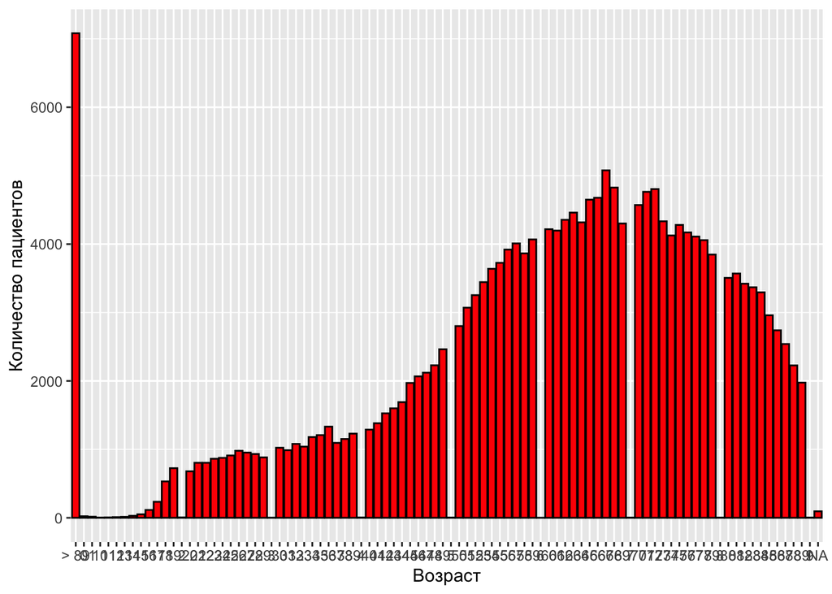